# Capstone Milestone: Exploratory Data Analysis

### Exploring patterns

In this section I use the functions created for calculating and sorting n-grams on the sample corpuses.

The n-grams for the blogs sample are:

```r
corpus.blogs = CreateCorpus(blogs)
corpus.blogs = CleanCorpus(corpus.blogs)
# Create Unigrams for blogs
blogs.tdm.unigram = CreateUnigram(corpus.blogs)
blogs.df.unigram = SortFreq(blogs.tdm.unigram)
head(blogs.df.unigram, 5)
```

```
##      word freq
## the   the 1009
## one   one  717
## will will  618
## just just  575
## like like  533
```

```r
# Create Bigrams for blogs
blogs.tdm.bigram = CreateBigrams(corpus.blogs)
blogs.df.bigram = SortFreq(blogs.tdm.bigram)
head(blogs.df.bigram, 5)
```

```
##            word freq
## i think i think  133
## i know   i know  128
## i can     i can   88
## i love   i love   81
## i will   i will   73
```

```r
# Create Trigrams for blogs
blogs.tdm.trigram = CreateTrigrams(corpus.blogs)
blogs.df.trigram = SortFreq(blogs.tdm.trigram)
head(blogs.df.trigram, 5)
```

```
##                    word freq
## i know i       i know i   23
## i think i     i think i   20
## i dont know i dont know   14
## i thought i i thought i   14
## i feel like i feel like   11
```

The n-grams for the twitter sample are:

```r
corpus.twitter = CreateCorpus(twitter)
corpus.twitter = CleanCorpus(corpus.twitter)
# Create Unigrams for twitter
twitter.tdm.unigram = CreateUnigram(corpus.twitter)
twitter.df.unigram = SortFreq(twitter.tdm.unigram)
head(twitter.df.unigram, 5)
```

```
##      word freq
## just just  323
## like like  270
## get   get  248
## the   the  231
## good good  210
```

```r
# Create Bigrams for twitter
twitter.tdm.bigram = CreateBigrams(corpus.twitter)
twitter.df.bigram = SortFreq(twitter.tdm.bigram)
head(twitter.df.bigram, 5)
```

```
##            word freq
## i love   i love   54
## i just   i just   44
## i think i think   43
## i can     i can   42
## i know   i know   42
```

```r
# Create Trigrams for twitter
twitter.tdm.trigram = CreateTrigrams(corpus.twitter)
twitter.df.trigram = SortFreq(twitter.tdm.trigram)
head(twitter.df.trigram, 5)
```

```
##                          word freq
## i know i             i know i    7
## i wish i             i wish i    6
## come see us       come see us    5
## i feel like       i feel like    5
## cake cake cake cake cake cake    4
```

The n-grams for the news sample are:

```r
corpus.news = CreateCorpus(news)
corpus.news = CleanCorpus(corpus.news)
# Create Unigrams for news
news.tdm.unigram = CreateUnigram(corpus.news)
news.df.unigram = SortFreq(news.tdm.unigram)
head(news.df.unigram, 5)
```

```
##      word freq
## the   the 1242
## said said 1192
## will will  570
## one   one  432
## new   new  359
```

```r
# Create Bigrams for news
news.tdm.bigram = CreateBigrams(corpus.news)
news.df.bigram = SortFreq(news.tdm.bigram)
head(news.df.bigram, 5)
```

```
##                    word freq
## last year     last year   78
## new york       new york   63
## st louis       st louis   62
## i think         i think   61
## high school high school   45
```

```r
# Create Trigrams for news
news.tdm.trigram = CreateTrigrams(corpus.news)
news.df.trigram = SortFreq(news.tdm.trigram)
head(news.df.trigram, 5)
```

```
##                                          word freq
## president barack obama president barack obama   16
## st louis county               st louis county    7
## cents per share               cents per share    6
## new york city                   new york city    6
## said i think                     said i think    6
```

### Plots

In this section I built some “pretty” exploratory graphs to visualise and compare the n-grams of the three samples. For the unigrams:

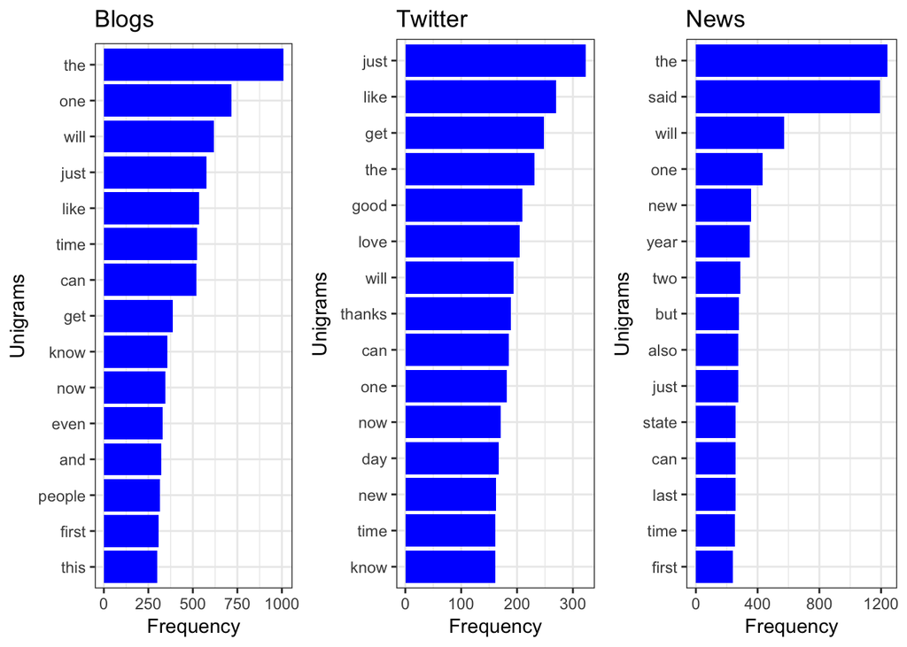

```r
library(gridExtra)
p1 = ggplot(head(blogs.df.unigram, 15), aes(reorder(word, freq),
    freq)) + geom_bar(stat = "identity", fill = "blue") + coord_flip() +
    xlab("Unigrams") + ylab("Frequency") + ggtitle("Blogs") +
    theme_bw()

p2 = ggplot(head(twitter.df.unigram, 15), aes(reorder(word, freq),
    freq)) + geom_bar(stat = "identity", fill = "blue") + coord_flip() +
    xlab("Unigrams") + ylab("Frequency") + ggtitle("Twitter") +
    theme_bw()

p3 = ggplot(head(news.df.unigram, 15), aes(reorder(word, freq),
    freq)) + geom_bar(stat = "identity", fill = "blue") + coord_flip() +
    xlab("Unigrams") + ylab("Frequency") + ggtitle("News") +
    theme_bw()


grid.arrange(p1, p2, p3, nrow = 1)
```

For the bigrams:

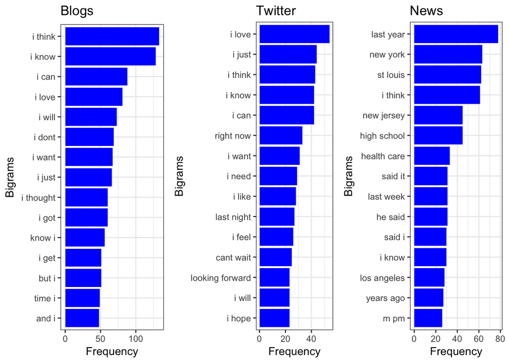

```r
p1 = ggplot(head(blogs.df.bigram, 15), aes(reorder(word, freq),
    freq)) + geom_bar(stat = "identity", fill = "blue") + coord_flip() +
    xlab("Bigrams") + ylab("Frequency") + ggtitle("Blogs") +
    theme_bw()

p2 = ggplot(head(twitter.df.bigram, 15), aes(reorder(word, freq),
    freq)) + geom_bar(stat = "identity", fill = "blue") + coord_flip() +
    xlab("Bigrams") + ylab("Frequency") + ggtitle("Twitter") +
    theme_bw()

p3 = ggplot(head(news.df.bigram, 15), aes(reorder(word, freq),
    freq)) + geom_bar(stat = "identity", fill = "blue") + coord_flip() +
    xlab("Bigrams") + ylab("Frequency") + ggtitle("News") + theme_bw()


grid.arrange(p1, p2, p3, nrow = 1)
```

For the Trigrams:

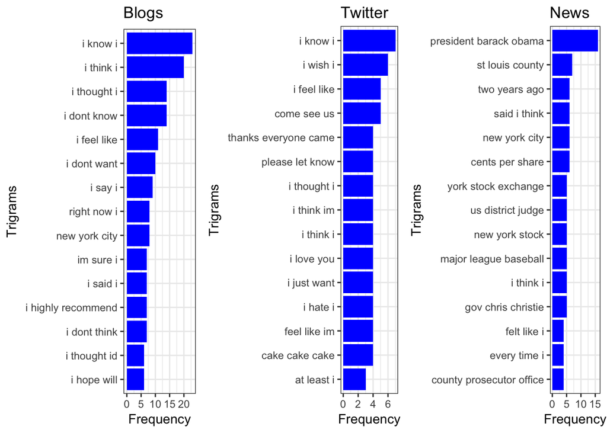

```r
p1 = ggplot(head(blogs.df.trigram, 15), aes(reorder(word, freq),
    freq)) + geom_bar(stat = "identity", fill = "blue") + coord_flip() +
    xlab("Trigrams") + ylab("Frequency") + ggtitle("Blogs") +
    theme_bw()

p2 = ggplot(head(twitter.df.trigram, 15), aes(reorder(word, freq),
    freq)) + geom_bar(stat = "identity", fill = "blue") + coord_flip() +
    xlab("Trigrams") + ylab("Frequency") + ggtitle("Twitter") +
    theme_bw()

p3 = ggplot(head(news.df.trigram, 15), aes(reorder(word, freq),
    freq)) + geom_bar(stat = "identity", fill = "blue") + coord_flip() +
    xlab("Trigrams") + ylab("Frequency") + ggtitle("News") +
    theme_bw()

grid.arrange(p1, p2, p3, nrow = 1)
```

## Conclusions and Next Step

Further work will be carryied out to create a predictive model for text writing application. The model will incorporate knowledge of the structure of the data as well as some linguistics.